# Homework Assignment 1

Lena Ivens

Assigned: Oct 24, 2020, Due Sun Nov 01, 2020 11:59PM

## HW-1 Instructions

> Our class emphasizes clear communication of data analysis results to non-technical audiences. I expect your HTML output documents to be readable and well formatted. I expect you to put ample comments in your R code to make the code understandable. Along with accuracy of results, I am looking for quality of presentation as well. This homework is due by **11:59PM on Nov 01st**. To complete this assignment, follow these steps:
1. Create a new RStudio Project for this HW. Sync the project directory with a GitHub Repository (see instructions on Canvas on how to do that).
2. Download the `HW1.Rmd` file from Canvas. Save the file in the RStudio Project Directory.
3. Open `HW1.Rmd` in RStudio. Replace the “Your Name Here” text in the `author:` field with your name.
4. Supply your solutions to the homework by editing `HW1.Rmd`.
5. Run your code in the Console and Knit HTML frequently to check for errors.
6. You may find it easier to solve a problem by interacting only with the Console at first.
7. When you have completed the homework please check that your knits correctly when you click `Knit HTML`.
8. “Push” all your local changes to the GitHub Repo for the project.
9. Submit your RMD file, the HTML output and a link to your GitHub Repo on Canvas.

## Data frame basics

We will continue working with the nycflights dataset we looked at in class. **Please be sure to keep the data file in the same directory as the RMD file - your project directory.**

First - make sure that you are reading the data correctly and doing all the data cleaning steps that we did in class. Feel free to go beyond our class work in cleaning the data if you feel the need.

I now would like you to answer the following - all in their own separate R code blocks.

### Data Exploration

Let’s first do some simple exploration of this data. I would like for you to answer each of the questions below with an **inline R code** integrated into the text and not in a separate R code block.

- *How many airlines are there?*  
  There are **16 airlines**.
- *How many flights there were by the airline with code `OO`?*  
  **32 flights** were conducted by the airline “OO”.
- *How long is the shortest flight out of any NYC airport?*  
  The shortest flight out of NYC took only **20 minutes**.
- *How many flights where there by United Airlines (code: UA) on Jan 12th 2013?*  
  On Jan 12th 2013, there were **112 flights** by “UA”.

### Arrival Delay

Lets focus on Arrival Delay.

- *What was the average arrival delay for all airports and all airlines combined in Jan 2013?*  
  The average arrival delay in January 2013 was **6.13 minutes**.
- *Whats was the median arrival delay for all airports and all airlines combined in Jan 2013?*  
  The median was **-3 minutes**.

Based on your answers to the two questions above, what can you say about the distribution of arrival delays? Provide your answer in a text paragraph form.

> Since the mean is greater than the median, the distribution is right-skewed. From that we can conclude that more than half of Jan 2013 flights arrived early. If we look at the data, we also see that there are many outliers in the (> 500 minute delays) which distort the mean delay time.

### Airline Performance

Lets see if all airlines are equally terrible as far as flight arrival delays are concerned. For this question you will have to make sure that airline column is coded as a factor.

- Calculate average arrival delays by airline
- Draw a Bar Plot of Average Arrival Delays for all the Airlines

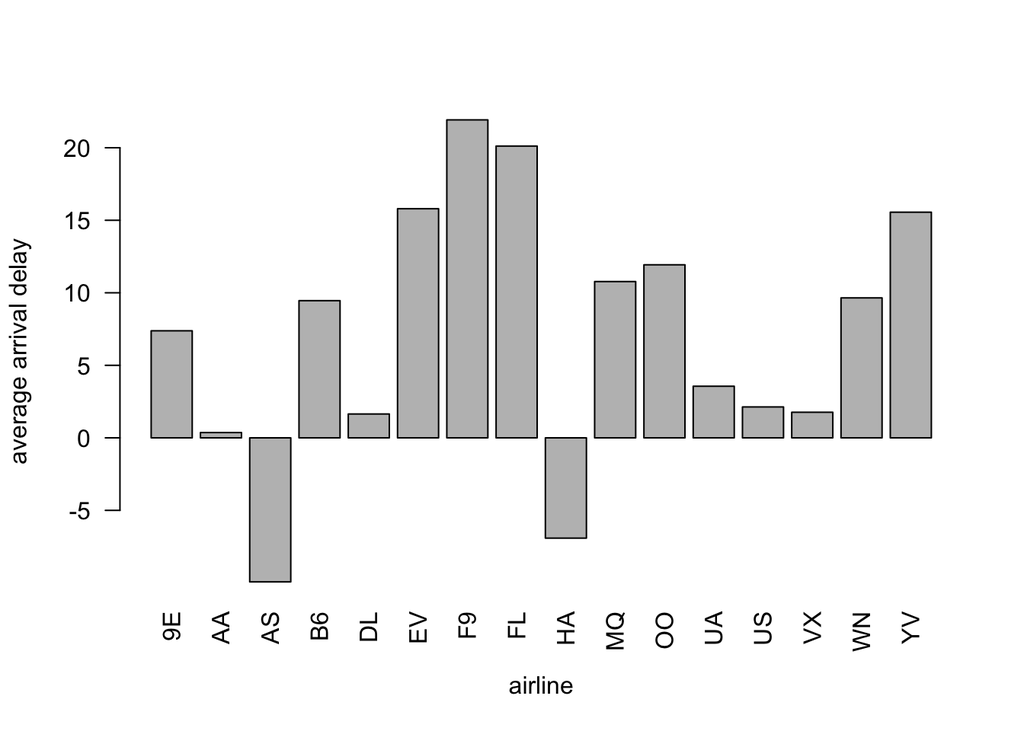

- *Which airline has the highest average arrival delay? Which airline has the smallest average arrival delay? Are there airlines that actually have negative average delay?*  
  Airline **F9** has with **21.92 minutes** the highest average arrival delay, whereas Airline **AS** has the lowest average arrival delay and arrives on average **9.931 minutes** early. As shown by the Bar Plot, **AS** and **HA** have negative average delays.

### Air Gain

Create a new column named airgain such that airgain = (departure delay - arrival delay) : this is the amount of delay a flight made up while in air.

1. Explore airgain data - calculate suitable descriptive statistics and appropriate graphics to better understand this data. This part is open ended - you do what you feel works best for you.

```
##    Min. 1st Qu.  Median    Mean 3rd Qu.    Max.    NA's
## -196.00   -3.00    7.00    5.66   17.00  109.00    9430
```

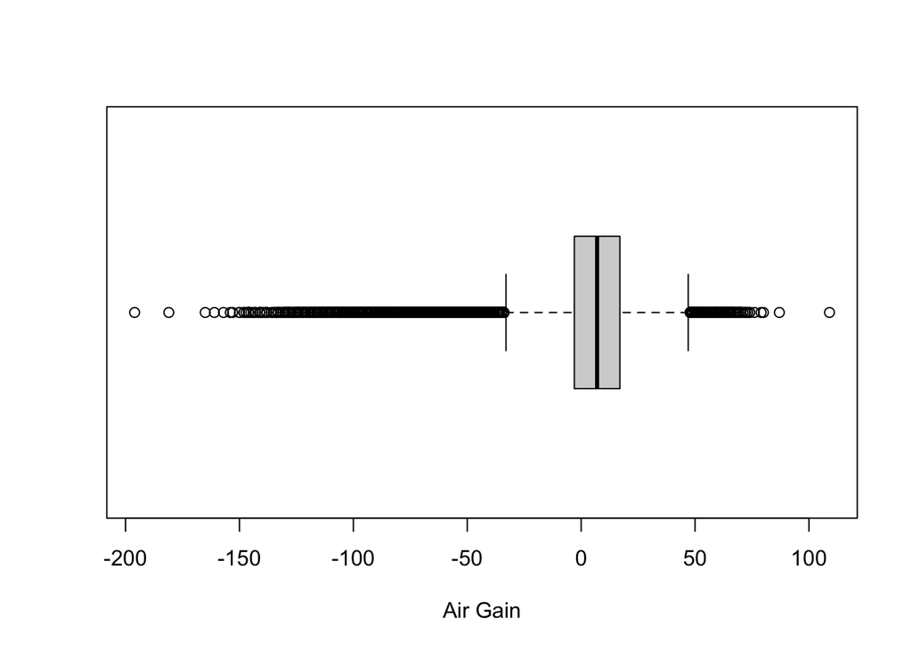

2. Answer the questions:
- *do airlines actually gain any time when in air on average?*  
  On average, airlines gain **5.66 minutes**. The boxplot above also shows that the median and quartiles skew slightly above 0, indicating that even without outliers, airlines gain time when in air.
- *Calculate average airgain for different airlines - which airlines do a better job, which do a worse job?*  
  Airline **AS** gains with **15.76 minutes** the most time in the air, whereas Airline **F9** actually loses on average **1.72 minutes** in the air, which would also explain the fact that **F9** notes the highest average delay.
- Build a graphic of average airgain for different airlines sorted by airgain. We want to graphically visualize which airlines are good at “catching up” when in air and which airlines actually lose time further after taking off.

```
##     9E     AA     AS     B6     DL     EV     F9     FL     HA     MQ     OO
##  9.060  8.205 15.762  3.510  7.580  4.042 -1.720 -1.510 11.816 -0.329  0.655
##     UA     US     VX     WN     YV
##  8.459  1.615 10.992  8.013  3.342
```

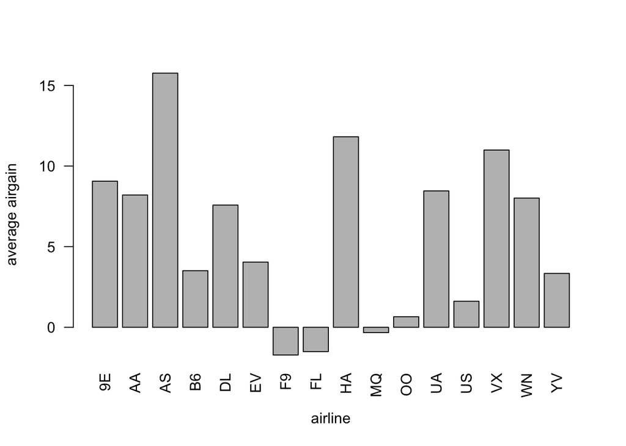